# Molecular Marker Assisted Plant Breeding

Introduction to Linear Models

Felipe Ferrão

University of Florida

**Objectives:**

**Extra information**

- [HOS 6236 – Website](https://lfelipe-ferrao.github.io/class/mas/)
- About the [author](https://lfelipe-ferrao.github.io/)
- About the [UF/IFAS Plant Breeding](https://programs.ifas.ufl.edu/plant-breeding/)

# Introduction to QTL mapping

- Look how the variation in the genotypic classes and the phenotypic variation on the left plot. Any insights?
- A simple and intuitive way to begin exploring this is to sort individuals by their phenotypic values and examine the corresponding marker information. What about now ? Any insights?
- Take a closer look at Marker 8—do you notice any pattern or trend emerging?

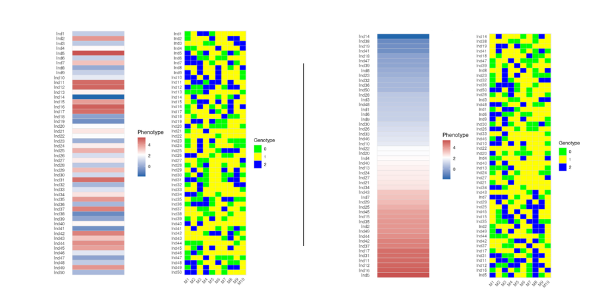

Left hand: unsorted | Right hand: sorted by the phenotypic expression

There are two main reasons why a computational approach is essential for QTL mapping, and we will not make a such kind of visual inspection:

- Scalability: As the number of markers and individuals increases, it becomes extremely difficult—and highly subjective—to visually identify which markers might be associated with a QTL.
- Formal Hypothesis Testing – Most importantly, we want to formally test hypotheses. For example, we may want to determine whether the mean phenotypic value for individuals with genotype AA (coded as 2) differs significantly from those with Aa (coded as 1) or aa (coded as 0). In addition, computational methods allow us to test the relative importance of different gene actions. Therefore, by applying statistical models, we can rigorously evaluate these effects and identify markers that are truly associated with trait variation—beyond what could be expected by chance.

# An introduction to linear models

## What is a model ?

- An abstraction of reality used to describe the relationship between two or more variables
- Many types of models (conceptual,graphical, mathematical)
- Always simplifications of reality
- Do not have to be complex ! (parsimonious)
- Can be used to test hypothesis !
- Essentially, all models are wrong, but some are useful (George Box)

See the example below, which presents two types of models.

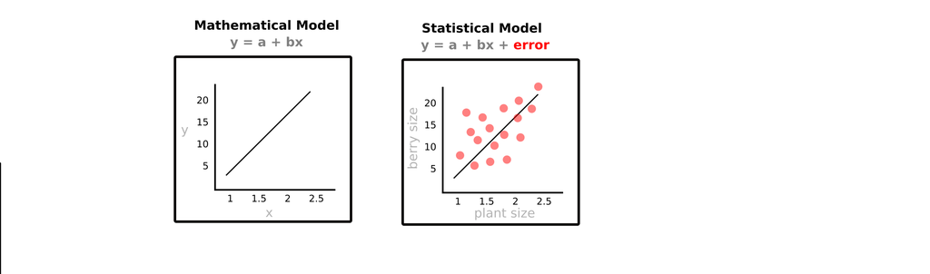

Mathematical vs. Statistical Model

- On the left-hand side, we have a **mathematical model**, which is deterministic and describes a direct relationship between two variables (e.g., *y ~ x*).
- In contrast, **statistical models** must account for **stochasticity**—the inherent randomness in data. As a result, statistical models always include an **error term** to capture uncertainty in the relationship.

## Statistical Model to solve problems in genetics

Let’s assume the following example:

- Two genotypes (A and B); with four clones (reps)
- Target trait: fruit size trait
- Question: How to model fruit size variation?
  - Overall mean common to all genotypes
  - Genetic effect associated to each genotype
  - Random error (stochastic)

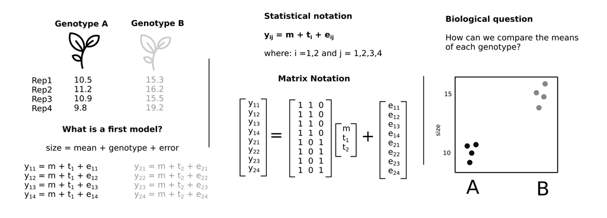

Visual representation about statistical models applied to genetics

There are several points to be highlighted in this representation:

- The importance of using matrix notation to represent problem in the interface of genetics and statistics
- Test hypothesis using biological questions. For example: compare the means

## Model assumptions

- Assumptions are necessary to simplify real world to workable model
- Important part to test hypothesis
- If assumptions are violated, inference may be invalid.

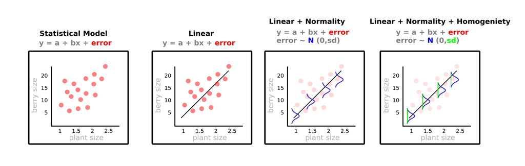

## ANOVA vs. Regression Analyses

Both panels illustrate the same underlying linear model, but one uses a categorical predictor while the other uses a numerical predictor. Although they fall under the same modeling framework, the interpretation and inference differ slightly between the two scenarios.

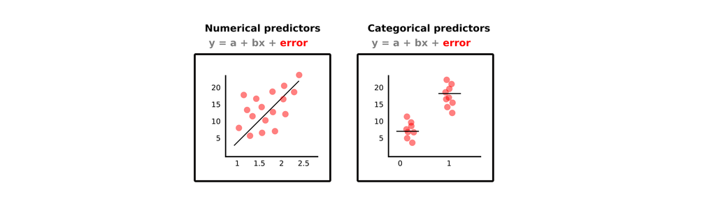

ANOVA vs. Regression models:Two different sides of the same coin !!

Interpretation:

- Regression: the expected change in the response per unit change in the predictor.
- ANOVA: slope parameter is the difference between the group means

### ANOVA (ANalysis Of VAriance)

- ANOVA is all about how can we allocate/partition variability
- Look the example below:

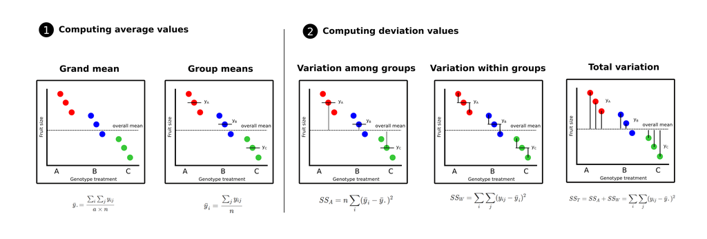

Allocate/partition variability in ANOVA models

These results are commonly presented in the famous ANOVA table, where we we partition the total variation into two components: **Among Groups** and **Within Groups**.

| Source of Variation | Degrees of Freedom (DF) | Sum of Squares (SS) | Mean Square (MS) | F-value |
| --- | --- | --- | --- | --- |
| Among Groups | $a - 1$ | $SS_A = \sum_{i=1}^{a} n_i(\bar{y}_{i\cdot} - \bar{y}_{\cdot\cdot})^2$ | $MS_A = \dfrac{SS_A}{a - 1}$ | $F = \dfrac{MS_A}{MS_E}$ |
| Within Groups | $N - a$ | $SS_E = \sum_{i=1}^{a} \sum_{j=1}^{n_i} (y_{ij} - \bar{y}_{i\cdot})^2$ | $MS_E = \dfrac{SS_E}{N - a}$ |  |
| **Total** | $N - 1$ | $SS_T = \sum_{i=1}^{a} \sum_{j=1}^{n_i} (y_{ij} - \bar{y}_{\cdot\cdot})^2$ |  |  |

Where:  
- $a$ = number of groups  
- $n_i$ = number of observations in group $i$  
- $N$ = total number of observations  
- $\bar{y}_{i\cdot}$ = mean of group $i$  
- $\bar{y}_{\cdot\cdot}$ = grand mean

When partitioning the total variance into its sources, we compare the treatment variance—the variation observed among the levels of the factor of interest—with the residual (error) variance, which captures unexplained or random variation.

- If treatment variance > residual variance: the treatment effect is likely important.
- If treatment variance < residual variance: random variation dominates, suggesting a weaker or negligible treatment effect.

**Example in R**

- Three genotypes (treatments or groups)
- Four replicates per genotype
- H0: There is no difference in the population means among the three genotypes.

```r
library(tidyr)

# Creating a data frame
df <- data.frame(
  Replicate = 1:4,
  GenoA = c(11, 13, 10, 12),
  GenoB = c(12, 10, 14, 13),
  GenoC = c(14, 17, 15, 15)
)

# Fitting anova model
df_long <- pivot_longer(
  df,
  cols = c(GenoA, GenoB, GenoC),
  names_to = "Genotype",
  values_to = "Fruit_size"
)

df_long$Genotype <- as.factor(df_long$Genotype)

fit.lm <- lm(Fruit_size ~ Genotype, data = df_long)
summary(fit.lm)
```

```
##
## Call:
## lm(formula = Fruit_size ~ Genotype, data = df_long)
##
## Residuals:
##     Min      1Q  Median      3Q     Max
## -2.2500 -0.6875 -0.2500  0.9375  1.7500
##
## Coefficients:
##               Estimate Std. Error t value Pr(>|t|)
## (Intercept)    11.5000     0.7169  16.042 6.29e-08 ***
## GenotypeGenoB   0.7500     1.0138   0.740  0.47828
## GenotypeGenoC   3.7500     1.0138   3.699  0.00493 **
## ---
## Signif. codes:  0 '***' 0.001 '**' 0.01 '*' 0.05 '.' 0.1 ' ' 1
##
## Residual standard error: 1.434 on 9 degrees of freedom
## Multiple R-squared:   0.63,  Adjusted R-squared:  0.5478
## F-statistic: 7.662 on 2 and 9 DF,  p-value: 0.0114
```

```r
# Check with this new parametrization
#fit.lm1 <- lm(Fruit_size ~ 0+Genotype, data = df_long)
#summary(fit.lm1)

# Traditional Anova table
fit.aov <- aov(Fruit_size ~ Genotype, data = df_long)
summary(fit.aov)
```

```
##             Df Sum Sq Mean Sq F value Pr(>F)
## Genotype     2   31.5  15.750   7.662 0.0114 *
## Residuals    9   18.5   2.056
## ---
## Signif. codes:  0 '***' 0.001 '**' 0.01 '*' 0.05 '.' 0.1 ' ' 1
```

**Fitting it by hand**

```r
# Residuals
fit.lm$residuals
sum(fit.lm$residuals^2)            # Residual sum of squares (RSS)
sum(fit.lm$residuals^2) / 9        # Residual mean square (MSE), df = 9

# Fitted values
fit.lm$fitted.values
# Treatment SS
sum((fit.lm$fitted.values - mean(fit.lm$fitted.values))^2)
# Treatment MS, df = 2
sum((fit.lm$fitted.values - mean(fit.lm$fitted.values))^2) / 2

# F test
# treatment mean square (df = 2)
MSa <- sum((fit.lm$fitted.values - mean(fit.lm$fitted.values))^2) / 2
# residual mean square (df = 9)
MSe <- sum(fit.lm$residuals^2) / 9
# F statistic
(F  <- MSa / MSe)
 # p-value
(p  <- pf(F, df1 = 2, df2 = 9, lower.tail = FALSE))
```

[output not shown]

### Simple Regression Analysis

Depending on the causal connections between two variables, *x* and *y*, the true relationship between both variables can be measured using linear regression.

In this case, we can represent it as:

$$y = \alpha + \beta x + e$$
where $\alpha$ is the y-intercept, $\beta$ is the slope of the line (also known as the regression coefficient), and *e* is the residual error. When information on *x* is used to predict *y*, *x* is referred to as the predictor or independent variable and *y* as the response or dependent variable.

The objective of linear regression analysis is to estimate the model parameters, $\alpha$ and $\beta$, that give the “best fit” for the joint distribution of $x$ and $y$. With those estimated values, we can perform predictions and inference. By inference, we refer to the steps necessary of estimating the regression model and assesing uncertainty in the fit.

The mathematical method of **least-squares linear regression** provides one such best-fit solution. In short, without making any assumptions about the true joint distribution of *x* and *y*, least-squares finds soluction for the parameters that minimizes the average value of the error – deviations of the observed y from the values predicted by the regression line.

Below there is a graphical explanation of least-squares linear regression with some important considerations:

- Straight lines can be drawn in multiple ways using different combinations of slope and intercept.
- What is the best fit?
- One way to solve this is to find the combination of slope and intercept that create a line and minimizes the error between the original and predicted values. Formally, finds the parameters values that minimizes the residual sum of squares.

[figure not shown]

Least-squares linear regression

Mathematically, the least-square solution for both $\alpha$ and $\beta$ can be computed as:

$$\alpha = \bar{y} -
\hat{\beta}\bar{x}$$
$$\hat{\beta} =
\dfrac{\sum (x_i-\bar{x})y_i}{\sum (x_i - \bar{x})^2} =
\dfrac{Cov(x,y)}{Var(x)}$$

Thus, the least-squares estimators for the intercept and slope of a linear regression are simple functions of the observed means, variances, and covariances. From the standpoint of quantitative genetics, this property is exceedingly useful, since such statistics are readily obtainable from phenotypic data.

We can go further and represent in terms of variance. The goal is to determine how much of the variation is explained by the regression line and the error. Below, how this is represented in a classical ANOVA table:

| Source of Variation | Degrees of Freedom | Sum of Squares | Mean of Squares | F-Ratio |
| --- | --- | --- | --- | --- |
| Regression | k | SSreg = Σ(Ŷ - Ȳ)² | MSreg = SSreg / k | MSreg / MSres |
| Residual | n-k-1 | SSres = Σ(Y - Ŷ)² | MSres = SSres / (n-k-1) |  |
| Total | n-1 | SStotal = Σ(Y - Ȳ)² |  |  |

Where:

- $R2 = \dfrac{SSreg}{SStotal} = \dfrac{\hat{b}_1 \sum x_iy_i}{\sum y_i^2}$

**Example in R**

- Two traits (fruit firmness and size), using arbitrary units
- Negative correlation
- Can variation in the response variable (Y) be explained by one or more predictor variables (X)?

```r
# Simulate two negatively correlated traits

# Sample size
n <- 100

# Trait means and SDs
mu_firm <- 6      # e.g., firmness score (arbitrary units)
mu_size <- 50     # e.g., fruit size (mm or g)
sd_firm <- 1
sd_size <- 10
rho <- -0.6       # target negative correlation

# Covariance matrix
Sigma <- matrix(c(sd_firm^2,              rho*sd_firm*sd_size,
                  rho*sd_firm*sd_size,    sd_size^2),
                nrow = 2, byrow = TRUE)

# Draw samples
library(MASS)
X <- MASS::mvrnorm(n = n, mu = c(mu_firm, mu_size), Sigma = Sigma)

# Build data frame
dat <- data.frame(FruitFirmness = X[,1],
                  FruitSize     = X[,2])



# Linear regression: Firmness ~ Size (negative slope expected)
fit <- lm(FruitFirmness ~ FruitSize, data = dat)
summary(fit)
```

```
##
## Call:
## lm(formula = FruitFirmness ~ FruitSize, data = dat)
##
## Residuals:
##      Min       1Q   Median       3Q      Max
## -2.23866 -0.52233 -0.08021  0.66129  1.82093
##
## Coefficients:
##              Estimate Std. Error t value Pr(>|t|)
## (Intercept)  8.763791   0.414916  21.122  < 2e-16 ***
## FruitSize   -0.055247   0.008339  -6.625 1.89e-09 ***
## ---
## Signif. codes:  0 '***' 0.001 '**' 0.01 '*' 0.05 '.' 0.1 ' ' 1
##
## Residual standard error: 0.8469 on 98 degrees of freedom
## Multiple R-squared:  0.3093, Adjusted R-squared:  0.3023
## F-statistic: 43.89 on 1 and 98 DF,  p-value: 1.886e-09
```

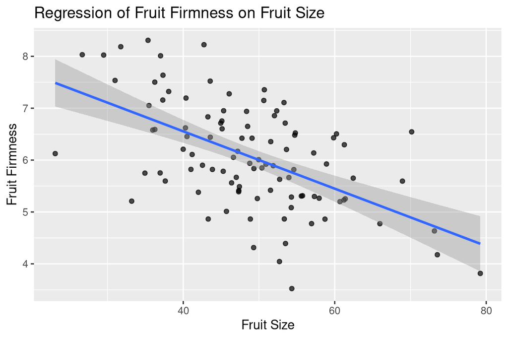

```r
library(ggplot2)
ggplot(dat, aes(x = FruitSize, y = FruitFirmness)) +
  geom_point(alpha = 0.7) +
  geom_smooth(method = "lm", se = TRUE) +
  labs(title = "Regression of Fruit Firmness on Fruit Size",
       x = "Fruit Size", y = "Fruit Firmness")
```

# Hands-on

- Simulated F2 population (`200ind_F2_10marker_simulation.csv`)
- 200 individuals and 10 genetic markers
- Exercise:
  - Download the data
  - Run an ANOVA model contrasting the three different treatments
  - Run a regression model
  - Record the p.values and define what marker is associated to the trait

# Conclusion

We rely on statistical models to establish associations and make inferences about the relationship between traits and their potential genetic causes. Consider a scenario where a phenotypic trait is measured in the field, and we also have data on genetic variation across individuals. In this context, QTL models provide a formal framework to test and quantify the association between specific genomic regions and variation in the trait of interest.

# References

- Faraway, J. J. (2014). Linear Models with R (2nd ed.). Chapman and Hall/CRC. ISBN: 978-1-4665-7476-4. [Link](https://www.taylorfrancis.com/books/mono/10.1201/b17144/linear-models-julian-faraway)
- Rencher, A. C., & Schaalje, G. B. (2008). Linear Models in Statistics (2nd ed.). John Wiley & Sons. ISBN: 978-0471754985. [Link](https://www.wiley.com/en-us/Linear+Models+in+Statistics%2C+2nd+Edition-p-9780471754985)